# BikeShare Analysis using Nonparametric Regression

Zhi Rong Tan

## Part 1

In a bike sharing system the process of obtaining membership, rental, and bike return is automated via a network of kiosk locations throughout a city. I will try to combine historical usage patterns with weather data to forecast bike rental demand in the Capital Bikeshare program in Washington, D.C. Predictions are evaluated using the root mean squared logarithmic error (RMSLE).

For the purpose of evaluating the models, I divide the training set into two parts: first 15 days of each month as the new training set and 16th to 19th as the validate set. Using this new training set, I will then fit a linear model on count numbers against (a subset of) the time and weather variables.

First, we note that the “Year” and “Day” variables are not required. I choose to select the “season” variable instead of the “month” variable (note both are highly correlated). In addition, since the temperature felt will affect riding rate more than the actual temperature, I will include “atemp” but exclude “temp”.

Next, we will transform the Season, Hour, Weather as factor variables.

```r
main_data <- read.csv("train.csv")
risk.mse <- function (val,predi) {
  sqrt(mean((val - predi)^2))
}

mse.actualcount <- function(val, pred) {
  sqrt(mean((log(1+val)-log (1+pred))^2))
}

main_data$hour <- as.factor(main_data$hour)
main_data$season <- as.factor(main_data$season)
main_data$weather <- as.factor(main_data$weather)

main_data$new.count <- log(main_data$count + 1)
main_data$mean.hr.logcount <- ave(main_data$new.count,
                                  main_data$daylabel)

#Next, divide the main dataset into our train and validation set.
train.data = main_data[which(main_data$day <= 15),]
valid.data = main_data[which(main_data$day > 15),]
```

Now, I want to include the following variables in my initial model, before performing backward regression model selection:

*Main Effects*: hour, season, holiday, workingday, weather (2 factors), atemp, humidity, windspeed; and

*Interaction*: atemp:holiday, atemp:workingday, weather:holiday, weather:workingday

```r
full1 = lm(new.count ~ daylabel + hour + season + holiday + workingday
           + weather + atemp + humidity + windspeed
           + atemp*holiday + atemp*workingday
           + weather*holiday + weather*workingday,
          data=train.data)

#Next, we do backward stepwise model selection.

#stepwise <- step(full1, data=train.data, direction="backward") #

#Based on the results, we find the new model
full.new = lm(new.count ~ daylabel + hour + season + workingday
           + weather + atemp + humidity + windspeed
           + atemp*workingday
           + weather*workingday,
          data=train.data)
summary(full.new)
```

```
##
## Call:
## lm(formula = new.count ~ daylabel + hour + season + workingday +
##     weather + atemp + humidity + windspeed + atemp * workingday +
##     weather * workingday, data = train.data)
##
## Residuals:
##    Min     1Q Median     3Q    Max
## -3.604 -0.291  0.028  0.361  2.491
##
## Coefficients: (2 not defined because of singularities)
##                        Estimate Std. Error t value Pr(>|t|)
## (Intercept)            2.490345   0.057230   43.51  < 2e-16 ***
## daylabel               0.001336   0.000035   38.17  < 2e-16 ***
## hour1                 -0.609082   0.044057  -13.82  < 2e-16 ***
## hour2                 -1.143238   0.044071  -25.94  < 2e-16 ***
## hour3                 -1.638619   0.044130  -37.13  < 2e-16 ***
## hour4                 -1.876792   0.044173  -42.49  < 2e-16 ***
## hour5                 -0.896867   0.044191  -20.30  < 2e-16 ***
## hour6                  0.291756   0.044178    6.60  4.2e-11 ***
## hour7                  1.260883   0.044122   28.58  < 2e-16 ***
## hour8                  1.883620   0.044071   42.74  < 2e-16 ***
## hour9                  1.550535   0.044116   35.15  < 2e-16 ***
## hour10                 1.214781   0.044262   27.45  < 2e-16 ***
## hour11                 1.331004   0.044535   29.89  < 2e-16 ***
## hour12                 1.529857   0.044853   34.11  < 2e-16 ***
## hour13                 1.496987   0.045166   33.14  < 2e-16 ***
## hour14                 1.410597   0.045403   31.07  < 2e-16 ***
## hour15                 1.467489   0.045474   32.27  < 2e-16 ***
## hour16                 1.723268   0.045389   37.97  < 2e-16 ***
## hour17                 2.146568   0.045196   47.49  < 2e-16 ***
## hour18                 2.061116   0.044948   45.86  < 2e-16 ***
## hour19                 1.765961   0.044528   39.66  < 2e-16 ***
## hour20                 1.469305   0.044317   33.15  < 2e-16 ***
## hour21                 1.219565   0.044156   27.62  < 2e-16 ***
## hour22                 0.969653   0.044096   21.99  < 2e-16 ***
## hour23                 0.591613   0.044073   13.42  < 2e-16 ***
## season2                0.307293   0.024122   12.74  < 2e-16 ***
## season3                0.139514   0.031149    4.48  7.6e-06 ***
## season4                0.239015   0.022059   10.84  < 2e-16 ***
## workingday             0.254244   0.041009    6.20  5.9e-10 ***
## weather1.5            -1.154999   0.418740   -2.76  0.00582 **
## weather2              -0.000758   0.027051   -0.03  0.97764
## weather2.5            -2.164530   0.592303   -3.65  0.00026 ***
## weather3              -0.441174   0.046714   -9.44  < 2e-16 ***
## weather4              -0.246123   0.592330   -0.42  0.67777
## atemp                  0.038119   0.001734   21.99  < 2e-16 ***
## humidity              -0.002712   0.000447   -6.07  1.4e-09 ***
## windspeed             -0.002251   0.000840   -2.68  0.00742 **
## workingday:atemp      -0.012311   0.001568   -7.85  4.6e-15 ***
## workingday:weather1.5        NA         NA      NA       NA
## workingday:weather2   -0.073662   0.032100   -2.29  0.02177 *
## workingday:weather2.5  1.111818   0.725267    1.53  0.12532
## workingday:weather3   -0.147111   0.053382   -2.76  0.00587 **
## workingday:weather4          NA         NA      NA       NA
## ---
## Signif. codes:  0 '***' 0.001 '**' 0.01 '*' 0.05 '.' 0.1 ' ' 1
##
## Residual standard error: 0.591 on 8599 degrees of freedom
## Multiple R-squared:  0.836,  Adjusted R-squared:  0.835
## F-statistic: 1.1e+03 on 40 and 8599 DF,  p-value: <2e-16
```

```r
#Find the prediction and the RMSLE.
predict.valid1 <- predict(full.new, newdata=valid.data)
riskq5a <- risk.mse(valid.data$new.count, predict.valid1)
riskq5a
```

```
## [1] 0.5823
```

The measured RMSLE for the validation set is 0.5823.

## Part 2

Next, I compute the mean hourly log counts for each day. To account for this main trend in terms of time, I then fit local linear regressions to the means against daylabel. After fitting the nonparametric curve, I will use the hourly residuals as my new responses, and fit the same model as in the previous part.

```r
library(locfit)
```

```
## locfit 1.5-9.1    2013-03-22
```

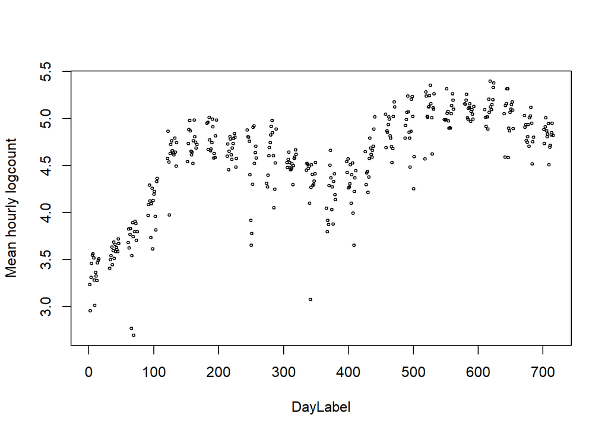

```r
#First plot the scatterplot of mean logcount against daylabel.
plot(train.data$daylabel, train.data$mean.hr.logcount,
     ylab="Mean hourly logcount", xlab="DayLabel", cex=0.5)
```

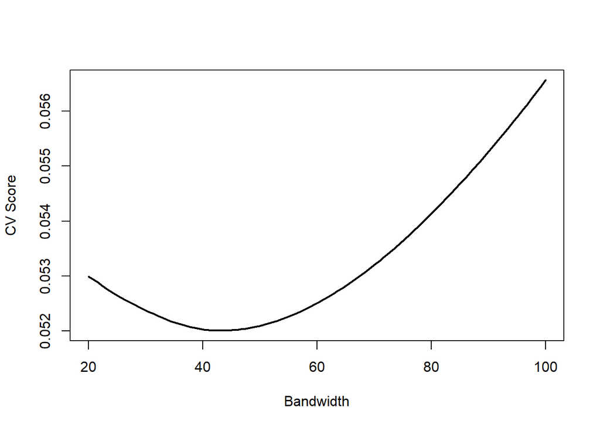

```r
#I will reorganize the data to make the algorithm run faster.
daymean <- aggregate(train.data$new.count, by=list(train.data$daylabel), mean)
colnames(daymean) = c("daylabel","logcount")

#Create the set of bandwidths.
gridaa = (seq(20, 100,length=100))
cvscore0 = rep(0, 100)
for (i in 1:100) {
  test.h <- gridaa[i]
  testlocfit = locfit(logcount~daylabel, data=daymean, alpha=c(0,test.h),
                      kern="gauss", deg=1, ev=dat())
  r <- residuals (testlocfit)
  l_ii <- fitted (testlocfit, what="infl")
  riskscore = mean((r/(1 - l_ii))^2)
  cvscore0[i] <- riskscore
}

#Plot the graph of CV score against bandwidth.
plot(gridaa, cvscore0, type="l", lwd=2,
     xlab = "Bandwidth", ylab="CV Score")
```

```r
#Find the OPTIMAL bandwidth for means against daylabel.
gridmat = matrix(0, ncol=2, nrow=100)
gridmat[, 2] = (seq(20, 100, length=100))
gcvs2 = gcvplot(logcount~daylabel, data=daymean, alpha=gridmat, deg=1, kern="gauss",ev=dat())
optband2 = max(gcvs2$alpha[gcvs2$values == min(gcvs2$values),2])
optband2
```

```
## [1] 42.63
```

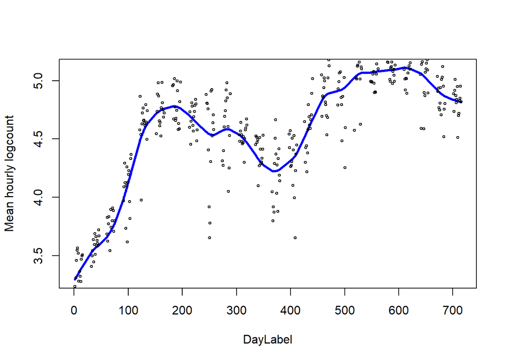

```r
#Fit the local linear regression model.
locfitopt2 = locfit(logcount~daylabel, data=daymean,
                    alpha=c(0,optband2), deg=1, maxk = 1000)
q2b.predict <- predict(locfitopt2, newdata=daymean$daylabel)

#Fit the regression model against the actual points in the scatterplot.
plot(daymean$daylabel, q2b.predict, type="l",
     ylab="Mean hourly logcount", xlab="DayLabel", lwd=3, col="blue")
points (logcount ~ daylabel , data = daymean, pch=1, cex=0.5)
```

The fitted local linear regression model line is in blue.

Next, use the hourly residuals as the new response, and fit the same model.

```r
predictb2 = predict(locfitopt2, newdata=train.data$daylabel)
train.data$logcount.res = train.data$new.count-predictb2

#Note that due to the level of significance in this new model,
#we have chosen to remove the variable weather*workingday from the model.
full.new.b = lm(logcount.res ~ daylabel + hour + season + workingday
           + weather + atemp + humidity + windspeed
           + atemp*workingday,
          data=train.data)
summary(full.new.b)
```

```
##
## Call:
## lm(formula = logcount.res ~ daylabel + hour + season + workingday +
##     weather + atemp + humidity + windspeed + atemp * workingday,
##     data = train.data)
##
## Residuals:
##    Min     1Q Median     3Q    Max
## -3.086 -0.282  0.034  0.351  2.239
##
## Coefficients:
##                    Estimate Std. Error t value        Pr(>|t|)
## (Intercept)      -0.9417131  0.0559608  -16.83         < 2e-16 ***
## daylabel         -0.0001051  0.0000346   -3.04         0.00239 **
## hour1            -0.6160080  0.0435323  -14.15         < 2e-16 ***
## hour2            -1.1568347  0.0435499  -26.56         < 2e-16 ***
## hour3            -1.6576037  0.0436027  -38.02         < 2e-16 ***
## hour4            -1.9039097  0.0436473  -43.62         < 2e-16 ***
## hour5            -0.9322818  0.0436460  -21.36         < 2e-16 ***
## hour6             0.2562719  0.0436549    5.87 0.0000000045085 ***
## hour7             1.2314276  0.0435968   28.25         < 2e-16 ***
## hour8             1.8694310  0.0435439   42.93         < 2e-16 ***
## hour9             1.5546594  0.0435844   35.67         < 2e-16 ***
## hour10            1.2382025  0.0437358   28.31         < 2e-16 ***
## hour11            1.3748405  0.0440056   31.24         < 2e-16 ***
## hour12            1.5911664  0.0443217   35.90         < 2e-16 ***
## hour13            1.5728766  0.0446314   35.24         < 2e-16 ***
## hour14            1.4979238  0.0448603   33.39         < 2e-16 ***
## hour15            1.5603247  0.0449161   34.74         < 2e-16 ***
## hour16            1.8145952  0.0448230   40.48         < 2e-16 ***
## hour17            2.2277387  0.0446291   49.92         < 2e-16 ***
## hour18            2.1294673  0.0444064   47.95         < 2e-16 ***
## hour19            1.8201542  0.0439928   41.37         < 2e-16 ***
## hour20            1.5102486  0.0437841   34.49         < 2e-16 ***
## hour21            1.2478585  0.0436315   28.60         < 2e-16 ***
## hour22            0.9891484  0.0435687   22.70         < 2e-16 ***
## hour23            0.6020490  0.0435422   13.83         < 2e-16 ***
## season2          -0.0831735  0.0238151   -3.49         0.00048 ***
## season3          -0.1607759  0.0307529   -5.23 0.0000001753871 ***
## season4           0.0071054  0.0217874    0.33         0.74434
## workingday        0.2758170  0.0388274    7.10 0.0000000000013 ***
## weather1.5       -0.9623050  0.4137913   -2.33         0.02006 *
## weather2         -0.0178500  0.0156698   -1.14         0.25468
## weather2.5       -1.1820198  0.3379692   -3.50         0.00047 ***
## weather3         -0.5377890  0.0261685  -20.55         < 2e-16 ***
## weather4         -0.3874513  0.5853392   -0.66         0.50804
## atemp             0.0207820  0.0017078   12.17         < 2e-16 ***
## humidity         -0.0024996  0.0004414   -5.66 0.0000000153633 ***
## windspeed        -0.0024351  0.0008303   -2.93         0.00337 **
## workingday:atemp -0.0144373  0.0015465   -9.34         < 2e-16 ***
## ---
## Signif. codes:  0 '***' 0.001 '**' 0.01 '*' 0.05 '.' 0.1 ' ' 1
##
## Residual standard error: 0.584 on 8602 degrees of freedom
## Multiple R-squared:  0.82,   Adjusted R-squared:  0.819
## F-statistic: 1.06e+03 on 37 and 8602 DF,  p-value: <2e-16
```

```r
#Note that now we need to estimate both the validation's mean logcount, and their residual count.
predict.meanlog <- predict(locfitopt2, newdata=valid.data$daylabel)
predict.residual <- predict(full.new.b, valid.data)
predict.valid2 <- predict.meanlog + predict.residual
riskq5b <- risk.mse(valid.data$new.count, predict.valid2)
riskq5b
```

```
## [1] 0.5709
```

The measured RMSLE for the validation set is 0.5709.

## Part 3

Now, I will fit an additive model.

```r
library(gam)

#Fit the additive model.
gamfit <-gam(new.count ~ s(daylabel) + s(temp) + s(atemp) + s(humidity) + s(windspeed)
             + s(atemp*workingday)
             + hour + season + workingday + weather,
            data=train.data)
summary(gamfit)
```

```
##
## Call: gam(formula = new.count ~ s(daylabel) + s(temp) + s(atemp) +
##     s(humidity) + s(windspeed) + s(atemp * workingday) + hour +
##     season + workingday + weather, data = train.data)
## Deviance Residuals:
##     Min      1Q  Median      3Q     Max
## -3.4905 -0.2856  0.0278  0.3405  2.3918
##
## (Dispersion Parameter for gaussian family taken to be 0.335)
##
##     Null Deviance: 18298 on 8639 degrees of freedom
## Residual Deviance: 2874 on 8583 degrees of freedom
## AIC: 15126
##
## Number of Local Scoring Iterations: 5
##
## Anova for Parametric Effects
##                         Df Sum Sq Mean Sq F value Pr(>F)
## s(daylabel)              1   1068    1068 3190.27 <2e-16 ***
## s(temp)                  1   1685    1685 5031.76 <2e-16 ***
## s(atemp)                 1      3       3    9.32 0.0023 **
## s(humidity)              1   2086    2086 6230.73 <2e-16 ***
## s(windspeed)             1     79      79  235.16 <2e-16 ***
## s(atemp * workingday)    1     29      29   85.35 <2e-16 ***
## hour                    23   9773     425 1268.88 <2e-16 ***
## season                   3     47      16   46.66 <2e-16 ***
## workingday               1     42      42  125.51 <2e-16 ***
## weather                  5    119      24   71.35 <2e-16 ***
## Residuals             8583   2874       0
## ---
## Signif. codes:  0 '***' 0.001 '**' 0.01 '*' 0.05 '.' 0.1 ' ' 1
##
## Anova for Nonparametric Effects
##                       Npar Df Npar F           Pr(F)
## (Intercept)
## s(daylabel)                 3   44.7         < 2e-16 ***
## s(temp)                     3   11.2 0.0000002593665 ***
## s(atemp)                    3   19.1 0.0000000000026 ***
## s(humidity)                 3   37.3         < 2e-16 ***
## s(windspeed)                3    2.6           0.049 *
## s(atemp * workingday)       3    9.7 0.0000023080257 ***
## hour
## season
## workingday
## weather
## ---
## Signif. codes:  0 '***' 0.001 '**' 0.01 '*' 0.05 '.' 0.1 ' ' 1
```

```r
#Next, predict for validation set, and find the risk.
predict.q5c <- predict(gamfit, newdata = valid.data)
riskq5c <- risk.mse(valid.data$new.count, predict.q5c)
riskq5c
```

```
## [1] 0.5652
```

The measured RMSLE for the validation set is 0.5652.

## Part 4

Using the methods from the previous 3 parts, I will create a final nonparametric model, and use it to predict my test set.

```r
#Since we have to replicate the process for both train and validation set,
#and the overall training and test set, I'll write some functions.

daycountfitted = function(dataset) {
  daymean <- aggregate(dataset$new.count, by=list(dataset$daylabel), mean)
  colnames(daymean) = c("daylabel","logcount")

  #Find the OPTIMAL bandwidth for means against daylabel.
  gridmat.d = matrix(0, ncol=2, nrow=100)
  gridmat.d[, 2] = (seq(20, 200, length=100))
  gcvs3 = gcvplot(logcount~daylabel, data=daymean, alpha=gridmat.d, kern="gauss",ev=dat())
  optband = max(gcvs3$alpha[gcvs3$values == min(gcvs3$values),2])
  optband

  #Fit the local linear regression model.
  locfitopt3 = locfit(logcount~daylabel, data=daymean,
                      alpha=c(0,optband), deg=1, maxk = 1000)
  return (locfitopt3)
}

predict.bikes = function(training, testing) {
  locfitdaylabel = daycountfitted(training)
  training$new.daylabel <- predict(locfitdaylabel, newdata=training$daylabel)
  testing$new.daylabel <- predict(locfitdaylabel, newdata=testing$daylabel)

  gamfit.5d <-gam(new.count ~ s(new.daylabel) + s(temp) + s(atemp) + s(humidity) + s(windspeed)
             + s(atemp*workingday)
             + hour + season + workingday + weather,
            data=training)
  predict.5d = predict(gamfit.5d, newdata = testing)
  normal.count = exp(predict.5d) -1
  return (normal.count)
}

#Now, let's test out the RMSLE for the final model, with the train and validation set.
#Prepare a new training dataset.
main_data2 <- read.csv("train.csv")
main_data2$hour <- as.factor(main_data2$hour)
main_data2$season <- as.factor(main_data2$season)
main_data2$weather <- as.factor(main_data2$weather)
main_data2$new.count <- log(main_data2$count + 1)
main_data2$mean.hr.logcount <- ave(main_data2$new.count,
                                  main_data2$daylabel)

#Next, divide the main dataset into our train and validation set.
train2.data = main_data2[which(main_data2$day <= 15),]
valid2.data = main_data2[which(main_data2$day > 15),]

predict2.valid <- predict.bikes(train2.data, valid2.data)

#What is the validation set RMSLE?
rmsle.final = mse.actualcount(valid2.data$count, predict2.valid)
rmsle.final
```

```
## [1] 0.5636
```

```r
#Finally, let's do this to our test set.
test_data <- read.csv("test.csv")
test_data$hour <- as.factor(test_data$hour)
test_data$season <- as.factor(test_data$season)
test_data$weather <- as.factor(test_data$weather)

predict.testset = predict.bikes(main_data2, test_data)
assgn1.5d <- as.vector(predict.testset)
write(assgn1.5d, "assn1-10456523.txt")
```

In the combined model, the RMSLE for the validation set is 0.5636. Subsequently, we train the model against using the overall training set (train + validation set), to predict the test set.